# Final Project

```python
import numpy as np
import pandas as pd
import matplotlib.pyplot as plt
import seaborn as sns
%matplotlib inline
from sklearn.metrics import accuracy_score
from sklearn.metrics import f1_score
```

```python
df = pd.read_csv(r"C:\Users\ahmed\Desktop\820 Project\Cardio_train.csv")
```

```python
df.head()
```

|  | id | age | gender | height | weight | ap_hi | ap_lo | cholesterol | gluc | smoke | alco | active | cardio |
| --- | --- | --- | --- | --- | --- | --- | --- | --- | --- | --- | --- | --- | --- |
| 0 | 0 | 18393 | 2 | 168 | 62.0 | 110 | 80 | 1 | 1 | 0 | 0 | 1 | 0 |
| 1 | 1 | 20228 | 1 | 156 | 85.0 | 140 | 90 | 3 | 1 | 0 | 0 | 1 | 1 |
| 2 | 2 | 18857 | 1 | 165 | 64.0 | 130 | 70 | 3 | 1 | 0 | 0 | 0 | 1 |
| 3 | 3 | 17623 | 2 | 169 | 82.0 | 150 | 100 | 1 | 1 | 0 | 0 | 1 | 1 |
| 4 | 4 | 17474 | 1 | 156 | 56.0 | 100 | 60 | 1 | 1 | 0 | 0 | 0 | 0 |

```python
df.shape
```

```
(70000, 13)
```

```python
df.info()
```

```
<class 'pandas.core.frame.DataFrame'>
RangeIndex: 70000 entries, 0 to 69999
Data columns (total 13 columns):
 #   Column       Non-Null Count  Dtype
---  ------       --------------  -----
 0   id           70000 non-null  int64
 1   age          70000 non-null  int64
 2   gender       70000 non-null  int64
 3   height       70000 non-null  int64
 4   weight       70000 non-null  float64
 5   ap_hi        70000 non-null  int64
 6   ap_lo        70000 non-null  int64
 7   cholesterol  70000 non-null  int64
 8   gluc         70000 non-null  int64
 9   smoke        70000 non-null  int64
 10  alco         70000 non-null  int64
 11  active       70000 non-null  int64
 12  cardio       70000 non-null  int64
dtypes: float64(1), int64(12)
memory usage: 6.9 MB
```

```python
df.describe()
```

|  | id | age | gender | height | weight | ap_hi | ap_lo | cholesterol | gluc | smoke | alco | active | cardio |
| --- | --- | --- | --- | --- | --- | --- | --- | --- | --- | --- | --- | --- | --- |
| count | 70000.000000 | 70000.000000 | 70000.000000 | 70000.000000 | 70000.000000 | 70000.000000 | 70000.000000 | 70000.000000 | 70000.000000 | 70000.000000 | 70000.000000 | 70000.000000 | 70000.000000 |
| mean | 49972.419900 | 19468.865814 | 1.349571 | 164.359229 | 74.205690 | 128.817286 | 96.630414 | 1.366871 | 1.226457 | 0.088129 | 0.053771 | 0.803729 | 0.499700 |
| std | 28851.302323 | 2467.251667 | 0.476838 | 8.210126 | 14.395757 | 154.011419 | 188.472530 | 0.680250 | 0.572270 | 0.283484 | 0.225568 | 0.397179 | 0.500003 |
| min | 0.000000 | 10798.000000 | 1.000000 | 55.000000 | 10.000000 | -150.000000 | -70.000000 | 1.000000 | 1.000000 | 0.000000 | 0.000000 | 0.000000 | 0.000000 |
| 25% | 25006.750000 | 17664.000000 | 1.000000 | 159.000000 | 65.000000 | 120.000000 | 80.000000 | 1.000000 | 1.000000 | 0.000000 | 0.000000 | 1.000000 | 0.000000 |
| 50% | 50001.500000 | 19703.000000 | 1.000000 | 165.000000 | 72.000000 | 120.000000 | 80.000000 | 1.000000 | 1.000000 | 0.000000 | 0.000000 | 1.000000 | 0.000000 |
| 75% | 74889.250000 | 21327.000000 | 2.000000 | 170.000000 | 82.000000 | 140.000000 | 90.000000 | 2.000000 | 1.000000 | 0.000000 | 0.000000 | 1.000000 | 1.000000 |
| max | 99999.000000 | 23713.000000 | 2.000000 | 250.000000 | 200.000000 | 16020.000000 | 11000.000000 | 3.000000 | 3.000000 | 1.000000 | 1.000000 | 1.000000 | 1.000000 |

```python
df.isna().sum()
```

```
id             0
age            0
gender         0
height         0
weight         0
ap_hi          0
ap_lo          0
cholesterol    0
gluc           0
smoke          0
alco           0
active         0
cardio         0
dtype: int64
```

We can even conclude from above data that we have no Null Values

From the above summary we can say that age is measurs in days, weight in kilograms and height in cm.. Lets look at the numerical variable first and how are they spread among target variable.

To check data has duplicate values.

```python
df.duplicated().sum()
```

```
0
```

```python
df.drop_duplicates(inplace=True)
```

Next step is analyzing the data how one variable is effevting another variable first is the count plot how manty people have positive and negative diagnosis.Our target feature is cardio which has a binary values. 0 = Negative Diagnosis, 1 = Positive Diagnosis

```python
df['cardio'].value_counts(normalize = True)
```

```
0    0.5003
1    0.4997
Name: cardio, dtype: float64
```

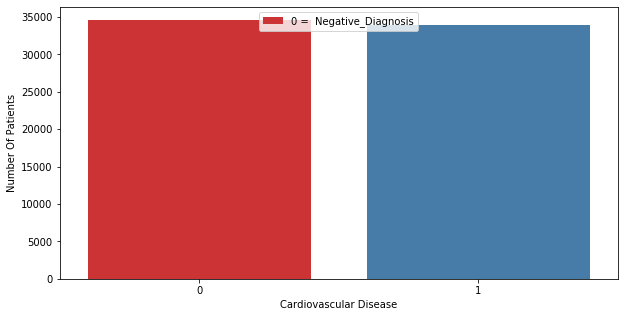

```python
plt.figure(figsize= (10,5))
sns.countplot(df['cardio'], palette = "Set1")
plt.xlabel('Cardiovascular Disease')
plt.ylabel('Number Of Patients')
plt.legend(loc = 'upper center', labels =['0 =  Negative_Diagnosis', '1 = Positive Diagnosis'])
```

From our countplot we checked target variable, it looks like is pretty balnaced.

ID column is a randomly generated value for a patient, and it does not affect the patient’s health. Hence, we do not need this for analysis and is removed from the dataset.

```python
df.drop(['id'], axis = 1, inplace = True)
```

```python
df['age'] = df['age']/365
```

To see the distribution of age.

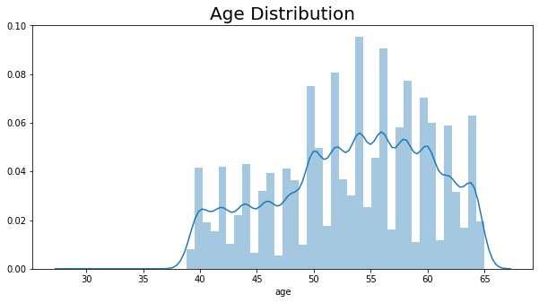

```python
plt.figure(figsize= (10,5))
sns.distplot(df['age'], bins = 50)
plt.title('Age Distribution', fontsize= 20)
```

Distribution of age is between 29 - 65. Mostly people we have is between 45 - 65.

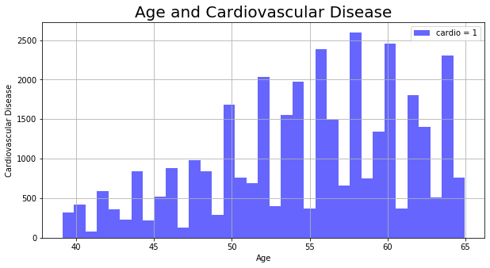

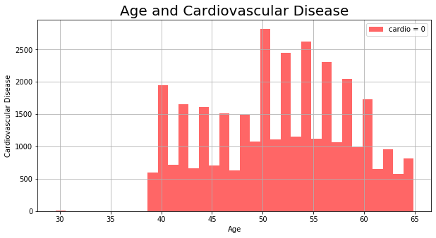

```python
plt.figure(figsize=(10,5))
df[df['cardio']== 1]['age'].hist(bins = 35, color = 'blue', label = 'cardio = 1', alpha = 0.6)
plt.title('Age and Cardiovascular Disease', fontsize= 20)
plt.xlabel('Age')
plt.ylabel('Cardiovascular Disease')
plt.legend()

plt.figure(figsize=(10,5))
df[df['cardio']== 0]['age'].hist(bins = 35, color = 'red', label = 'cardio = 0', alpha = 0.6)
plt.title('Age and Cardiovascular Disease', fontsize= 20)
plt.xlabel('Age')
plt.ylabel('Cardiovascular Disease')
plt.legend()
```

From this visual we can say that people who are older are more prone to Cardiovascular disease.

Coming into gender ratio , in our dataset we have classified gender variable by categories 1 and 2. 1 = Female, 2 = Male.

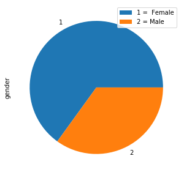

```python
plt.figure(figsize= (5,5))
df["gender"].value_counts().plot(kind='pie')
plt.legend(loc = 'upper right', labels =['1 =  Female','2 = Male'])
```

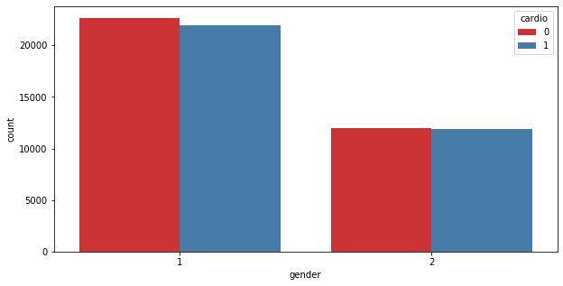

```python
plt.figure(figsize= (10,5))
sns.countplot(x='gender', hue='cardio', data = df, palette="Set1")
```

Visualizations shows the the disease label is equally distributed but the gender population is not balanced.

According to Canadian Health board , the factors which are increasing risk of CVD are :

High blood pressure (hypertension) Abnormal cholesterol and high triglycerides Obesity Lack of physical activity Poorly controlled blood sugars (too high) or out of normal range Smoking Reference Link : CVD-Heart.org

From our dataset and with visualizations we need to prove these factors are true or atleast a strong inference to assume it is false.

We are checking height with the target variable. height is given in cm.

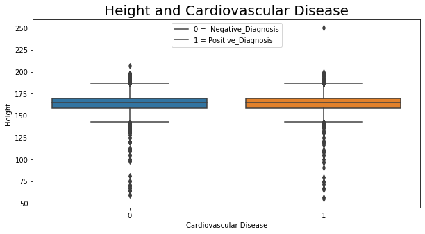

```python
plt.figure(figsize= (10,5))
sns.boxplot(df['cardio'],(df['height']))
plt.title('Height and Cardiovascular Disease', fontsize= 20)
plt.xlabel('Cardiovascular Disease')
plt.ylabel('Height')
plt.legend(loc = 'upper center', labels =['0 =  Negative_Diagnosis','1 = Positive_Diagnosis'])
```

As we can see both diagnosis and non diagnosis have the dame height.Hence Height does not effect the persons health.Secondly, we can see that the people with below 4 feet and above 7 feet in height so it means there are some outliers in it.

Now checking the weight attribute with our target variable. Aas we know hat obesity is the main factor for disease.

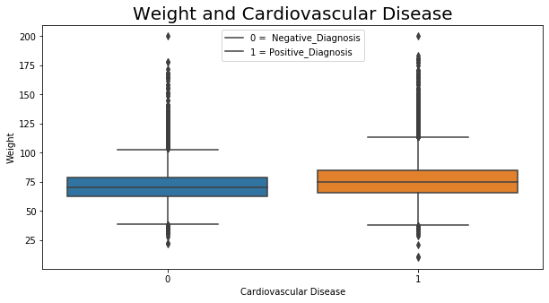

```python
plt.figure(figsize= (10,5))
sns.boxplot(df['cardio'],(df['weight']))
plt.title('Weight and Cardiovascular Disease', fontsize= 20)
plt.xlabel('Cardiovascular Disease')
plt.ylabel('Weight')
plt.legend(loc = 'upper center', labels =['0 =  Negative_Diagnosis','1 = Positive_Diagnosis'])
```

[figure not shown]

```python
plt.figure(figsize= (10,5))
sns.scatterplot(x= 'height', y= 'weight', hue= 'cardio', data= df)
```

From the above plots we can see that the people who have obesity or more weight they are more prone to cardiac arrest. Secondly, there are people whose weight is less than 25kg and morethan 175kg which looks like an outlier. We will eliminate all such records from our analysis.

Removing of outliers

```python
outlier1 = ((df["height"]<=110) |(df['height']>= 200)
             | (df["weight"]<=25) | (df["weight"] >= 175))
```

```python
df = df[~outlier1]
```

Afterremoving the ouliers from weight and height column now we have bigger picture but as compare to weight we can say that people who have more weight they are more prone to disease.

Checking out the 2 variables together for blood Pressure.

Diastolic Blood Pressure--ap_lo(Low blood pressrure) Systolic Blood Pressure-- ap_hi(High Blood Pressure)

For Systolic blood pressure , the range should be 90 - 180 mm.

For Diastolic blood pressure , the range should be 60 - 120 mm.

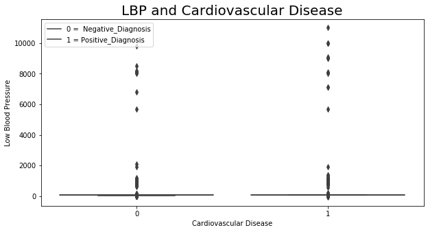

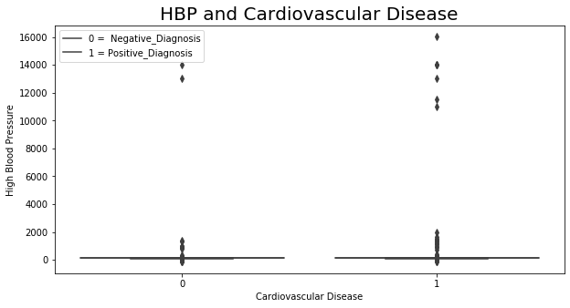

```python
plt.figure(figsize= (10,5))
sns.boxplot(df['cardio'],(df['ap_lo']))
plt.title('LBP and Cardiovascular Disease', fontsize= 20)
plt.xlabel('Cardiovascular Disease')
plt.ylabel('Low Blood Pressure')
plt.legend(loc = 'upper left', labels =['0 =  Negative_Diagnosis', '1 = Positive_Diagnosis'])

plt.figure(figsize= (10,5))
sns.boxplot(df['cardio'],(df['ap_hi']))
plt.title('HBP and Cardiovascular Disease', fontsize= 20)
plt.xlabel('Cardiovascular Disease')
plt.ylabel('High Blood Pressure')
plt.legend(loc = 'upper left', labels =['0 =  Negative_Diagnosis', '1 = Positive_Diagnosis'])
```

[figure not shown]

```python
plt.figure(figsize= (10,5))
sns.scatterplot(x= 'ap_hi', y= '', hue= 'cardio', data= df)
```

As we can see from the above plots the people who's blood pressure are not normal are more prone to cardiavascular disease. There ar lot of outliers in this two features. Thus we can drop the ap_hi outlier values over 200mm and lesser 80mm. We can aslo drop the ap_lp outlier values over 120mm and lesser 50mm. Because above these values the person cannot survive. For Systolic blood pressure , the range should be 90 - 180 mm.

For Diastolic blood pressure , the range should be 60 - 120 mm.

```python
outlier2 = ((df["ap_hi"]>200) | (df["ap_lo"]>120) | (df["ap_lo"]<50) | (df["ap_hi"]<=80))
```

```python
df = df[~outlier2]
```

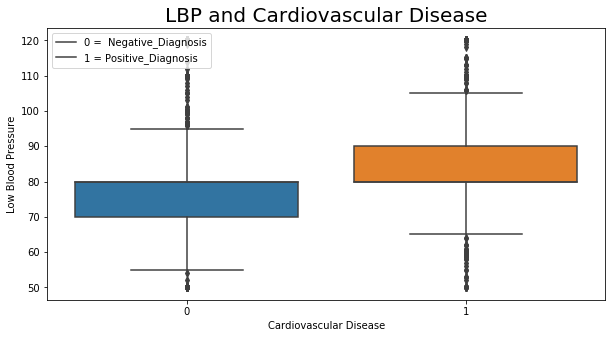

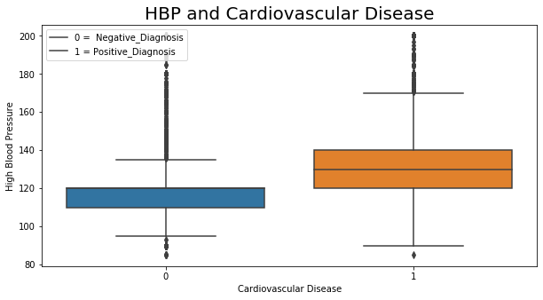

```python
plt.figure(figsize= (10,5))
sns.boxplot(df['cardio'],(df['ap_lo']))
plt.title('LBP and Cardiovascular Disease', fontsize= 20)
plt.xlabel('Cardiovascular Disease')
plt.ylabel('Low Blood Pressure')
plt.legend(loc = 'upper left', labels =['0 =  Negative_Diagnosis', '1 = Positive_Diagnosis'])

plt.figure(figsize= (10,5))
sns.boxplot(df['cardio'],(df['ap_hi']))
plt.title('HBP and Cardiovascular Disease', fontsize= 20)
plt.xlabel('Cardiovascular Disease')
plt.ylabel('High Blood Pressure')
plt.legend(loc = 'upper left', labels =['0 =  Negative_Diagnosis', '1 = Positive_Diagnosis'])
```

After removing the outliers , we can get the clear picture of the distribution of systolic and diastolic pressure.People who have blood pressure above normal having cardiovascular disease.

Afer removing all the ouliers and duplicate vlaues just checking how much data we have left for further proedure.

```python
df.shape
```

```
(68453, 12)
```

Checking the shape of dataset we removed almost 2% data from our original dataset.

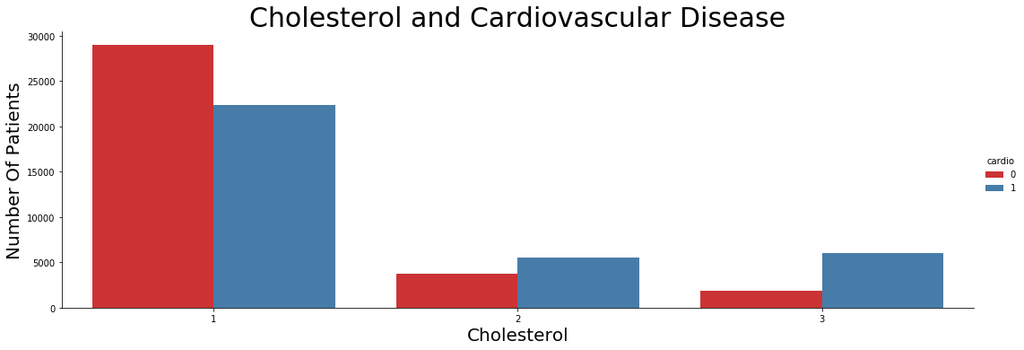

```python
plt.figure(figsize= (10,5))
sns.catplot("cholesterol", data=df,hue='cardio',aspect = 3.0, kind = 'count', palette="Set1")
plt.title('Cholesterol and Cardiovascular Disease', fontsize= 30)
plt.xlabel('Cholesterol', fontsize = 20)
plt.ylabel('Number Of Patients', fontsize = 20)
```

Having cholesterol levels "above normal" and "well above normal" increase an individuals chances of being diagnosed with cardiovascular disease. However, having "normal" cholesterol levels does not decrease your chances. There are many individuals with normal cholesterol levels and CVD.

76% of patients with cholesterol "well above normal" also have cardiovascular disease. The above plot shows that cholesterol has a great impact over the diseased state of a person.

Its to check diabetes(glucose level) of a person.

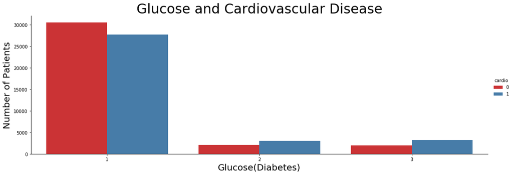

```python
plt.figure(figsize= (10,5))
sns.catplot("gluc", data=df,hue='cardio', aspect = 3.0, kind = 'count',palette="Set1")
plt.title('Glucose and Cardiovascular Disease', fontsize= 30)
plt.xlabel('Glucose(Diabetes)', fontsize = 20)
plt.ylabel('Number of Patients', fontsize = 20)
```

Glucose levels that are "normal" do not seem to have any relationship to having the disease or not. In fact, a patient has almost a 50% chance of having cardiovascular disease even with a normal glucose measurement. The risk of being diagnosed with cardiovascular disease increases with increasing levels of glucose.

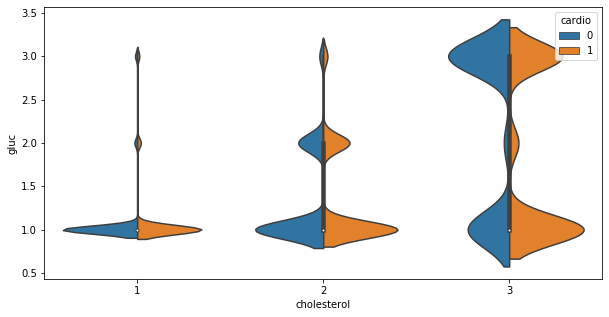

```python
plt.figure(figsize= (10,5))
sns.violinplot(x= 'cholesterol', y = 'gluc', data = df, hue = 'cardio', split = True)
```

Check whether drinking habits effect persons health. 0 = non-alcoholic, 1 = alcoholic.The patients are majorly non-alcoholic. But we need to check , the alcoholic are prone to cardio disease.

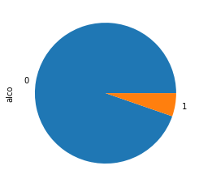

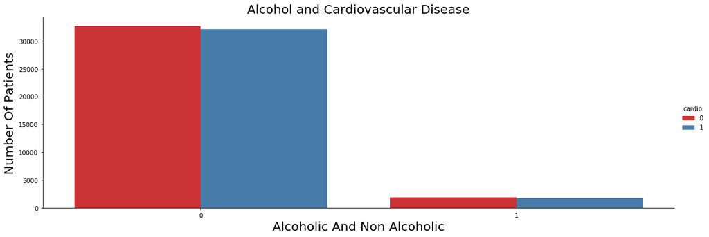

```python
df["alco"].value_counts().plot(kind='pie')
plt.figure(figsize= (10,5))
sns.catplot("alco", data=df,hue='cardio', aspect = 3.0, kind = 'count', palette="Set1")
plt.title('Alcohol and Cardiovascular Disease', fontsize= 20)
plt.xlabel('Alcoholic And Non Alcoholic', fontsize = 20)
plt.ylabel('Number Of Patients', fontsize = 20)
```

By plots and dataset given , alcohol consumption does not seem to be contributing feature to cardiovascular disease . If alcohol consumption seems to be factor it should have high cardio arrest count.

Check whether smoking habits effect persons health. 0 = non-smokers, 1 = smokers.The patients are majorly non-smokers. But we need to check , the smokers are prone to cardio disease.

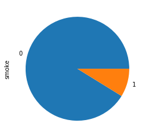

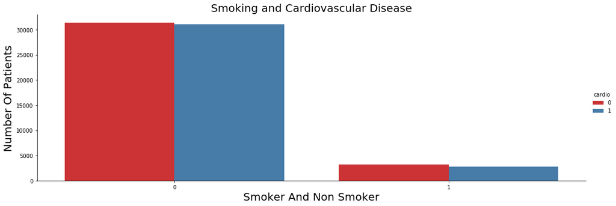

```python
df["smoke"].value_counts().plot(kind='pie')
plt.figure(figsize= (10,5))
sns.catplot("smoke", data=df,hue='cardio', aspect = 3.0, kind = 'count', palette="Set1")
plt.title('Smoking and Cardiovascular Disease', fontsize= 20)
plt.xlabel('Smoker And Non Smoker', fontsize = 20)
plt.ylabel('Number Of Patients', fontsize = 20)
```

One thing to observe is , the non smokers are somewhat more prone to cardio disease compare to smoking person with non cardio disease.

Checking that does physically activivity effect persons health or not. There are more physically active people in the dataset.. 0 = Non Active, 1 = active.

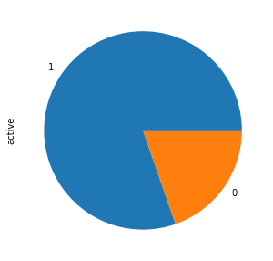

```python
plt.figure(figsize= (10,5))
df["active"].value_counts().plot(kind='pie')
```

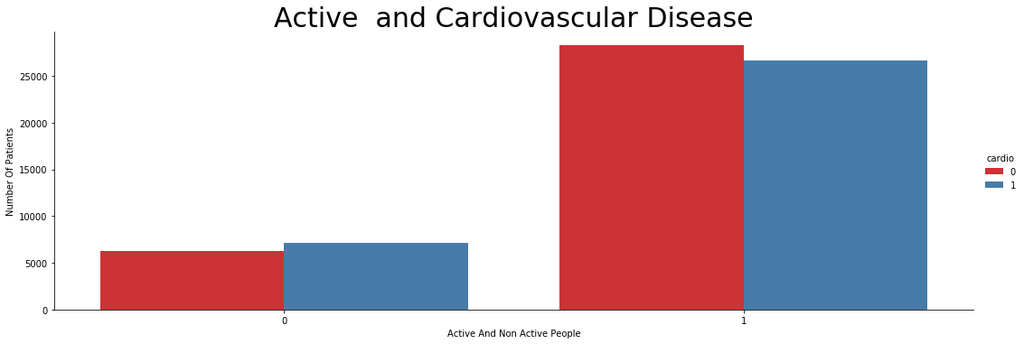

```python
plt.figure(figsize= (10,5))
sns.catplot("active", data=df,hue='cardio', aspect = 3.0, kind = 'count', palette="Set1")
plt.title('Active  and Cardiovascular Disease', fontsize= 30)
plt.xlabel('Active And Non Active People', fontsize = 10)
plt.ylabel('Number Of Patients', fontsize = 10)
```

whenever we have height and weight, we can calculate BMI. It seems better to get another Feature BMI. Who knows we may get some better insights

```python
df["BMI"] = df.weight / (df.height / 100) ** 2
```

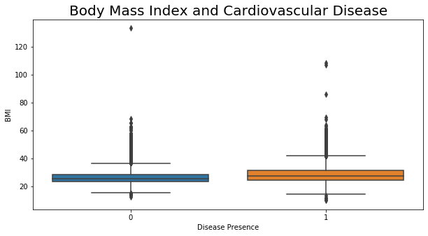

```python
plt.figure(figsize= (10,5))
sns.boxplot(x = 'cardio', y= 'BMI', data= df)
plt.title('Body Mass Index and Cardiovascular Disease', fontsize= 20)
plt.xlabel('Disease Presence')
plt.ylabel('BMI')
```

A quick boxplot shows that individuals with CVD have, on average, higher body mass indexes than those that do not have CVD.

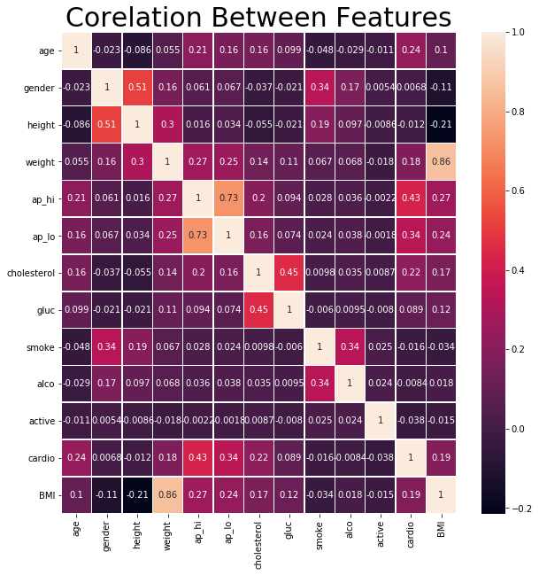

```python
plt.rcParams['figure.figsize'] = (10, 10)
sns.heatmap(df.corr(), annot = True, linewidths=.5)
plt.title('Corelation Between Features', fontsize = 30)
plt.show()
```

We can see from correlation map easily; cholesterol, blood pressure (ap_hi and ap_low both) and age have a powerful relationship with our target variable (cardiovascular diseases).

In the above heatmap, there are correlations among gender and height.

Smoke and alcohol have a correlation.

Glucose(diabetes) and cholesterol have a strong relationship among them.

Blood Pressur(ap_hi and ap_lo) have a strong relationshop among them.

Machine Learning Algorithms

```python
from sklearn.model_selection import train_test_split
```

```python
from sklearn.model_selection import train_test_split
```

```python
X = df.drop('cardio', axis = 1)
y = df['cardio']
X_train, X_test, y_train, y_test = train_test_split(X, y, test_size=0.33, random_state=101)
```

```python
from sklearn.linear_model import LogisticRegression
```

```python
logmodel = LogisticRegression()
logmodel.fit(X_train, y_train)
```

```
LogisticRegression(C=1.0, class_weight=None, dual=False, fit_intercept=True,
                   intercept_scaling=1, l1_ratio=None, max_iter=100,
                   multi_class='auto', n_jobs=None, penalty='l2',
                   random_state=None, solver='lbfgs', tol=0.0001, verbose=0,
                   warm_start=False)
```

```python
predictions_log = logmodel.predict(X_test)
```

```python
from sklearn.metrics import classification_report, confusion_matrix
print(classification_report(y_test, predictions_log))
print(confusion_matrix(y_test, predictions_log))
```

```
              precision    recall  f1-score   support

           0       0.70      0.78      0.74     11377
           1       0.75      0.66      0.71     11213

    accuracy                           0.72     22590
   macro avg       0.73      0.72      0.72     22590
weighted avg       0.73      0.72      0.72     22590

[[8928 2449]
 [3764 7449]]
```

```python
accuracy_log = accuracy_score(y_test, predictions_log)
accuracy_log
```

```
0.7249667994687915
```

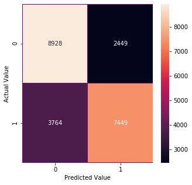

```python
cm = confusion_matrix(y_test, predictions_log)
f, ax = plt.subplots(figsize=(5,5))
sns.heatmap(cm,fmt=".0f", annot=True,linewidths=0.2, linecolor="purple", ax=ax)
plt.xlabel("Predicted Value")
plt.ylabel("Actual Value")
plt.show()
```

```python
from sklearn.ensemble import RandomForestClassifier
```

```python
X = df.drop('cardio', axis = 1)
y = df['cardio']
X_train, X_test, y_train, y_test = train_test_split(X, y, test_size=0.33, random_state=101)
```

```python
rfc = RandomForestClassifier(n_estimators = 100)
```

```python
rfc.fit(X_train, y_train)
```

```
RandomForestClassifier(bootstrap=True, ccp_alpha=0.0, class_weight=None,
                       criterion='gini', max_depth=None, max_features='auto',
                       max_leaf_nodes=None, max_samples=None,
                       min_impurity_decrease=0.0, min_impurity_split=None,
                       min_samples_leaf=1, min_samples_split=2,
                       min_weight_fraction_leaf=0.0, n_estimators=100,
                       n_jobs=None, oob_score=False, random_state=None,
                       verbose=0, warm_start=False)
```

```python
predictions_rfc = rfc.predict(X_test)
```

```python
print(classification_report(y_test, predictions_rfc))
print(confusion_matrix(y_test, predictions_rfc))
```

```
              precision    recall  f1-score   support

           0       0.71      0.73      0.72     11377
           1       0.72      0.70      0.71     11213

    accuracy                           0.71     22590
   macro avg       0.71      0.71      0.71     22590
weighted avg       0.71      0.71      0.71     22590

[[8323 3054]
 [3419 7794]]
```

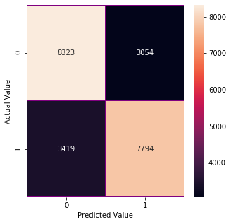

```python
cm = confusion_matrix(y_test, predictions_rfc)
f, ax = plt.subplots(figsize=(5,5))
sns.heatmap(cm,fmt=".0f", annot=True,linewidths=0.2, linecolor="purple", ax=ax)
plt.xlabel("Predicted Value")
plt.ylabel("Actual Value")
plt.show()
```

```python
accuracy_rfc = accuracy_score(y_test, predictions_rfc)
accuracy_rfc
```

```
0.7134572819831784
```

```python
X = df.drop('cardio', axis = 1)
y = df['cardio']
X_train, X_test, y_train, y_test = train_test_split(X, y, test_size=0.33, random_state=101)
```

```python
from sklearn.tree import DecisionTreeClassifier
```

```python
dtree = DecisionTreeClassifier()
```

```python
dtree.fit(X_train, y_train)
```

```
DecisionTreeClassifier(ccp_alpha=0.0, class_weight=None, criterion='gini',
                       max_depth=None, max_features=None, max_leaf_nodes=None,
                       min_impurity_decrease=0.0, min_impurity_split=None,
                       min_samples_leaf=1, min_samples_split=2,
                       min_weight_fraction_leaf=0.0, presort='deprecated',
                       random_state=None, splitter='best')
```

```python
predictions_dtree = dtree.predict(X_test)
```

```python
print(classification_report(y_test, predictions_dtree))
print(confusion_matrix(y_test, predictions_dtree))
```

```
              precision    recall  f1-score   support

           0       0.64      0.64      0.64     11377
           1       0.64      0.64      0.64     11213

    accuracy                           0.64     22590
   macro avg       0.64      0.64      0.64     22590
weighted avg       0.64      0.64      0.64     22590

[[7290 4087]
 [4043 7170]]
```

```python
accuracy_dtree = accuracy_score(y_test, predictions_dtree)
accuracy_dtree
```

```
0.6401062416998672
```

[figure not shown]

```python
cm = confusion_matrix(y_test, predictions_dtree)
f, ax = plt.subplots(figsize=(5,5))
sns.heatmap(cm,fmt=".0f", annot=True,linewidths=0.2, linecolor="purple", ax=ax)
plt.xlabel("Predicted Value")
plt.ylabel("Actual Value")
plt.show()
```

```python
from sklearn.neighbors import KNeighborsClassifier
```

```python
knn = KNeighborsClassifier(n_neighbors = 1)
```

```python
knn.fit(X_train, y_train)
```

```
KNeighborsClassifier(algorithm='auto', leaf_size=30, metric='minkowski',
                     metric_params=None, n_jobs=None, n_neighbors=1, p=2,
                     weights='uniform')
```

```python
pred = knn.predict(X_test)
```

```python
print(classification_report(y_test, pred))
print(confusion_matrix(y_test, pred))
```

```
              precision    recall  f1-score   support

           0       0.63      0.65      0.64     11377
           1       0.63      0.62      0.62     11213

    accuracy                           0.63     22590
   macro avg       0.63      0.63      0.63     22590
weighted avg       0.63      0.63      0.63     22590

[[7362 4015]
 [4310 6903]]
```

```python
error_rate = []
for i in range(1,40):
    knn = KNeighborsClassifier(n_neighbors = i)
    knn.fit(X_train,y_train)
    pred_i = knn.predict(X_test)
    error_rate.append(np.mean(pred_i !=y_test))
```

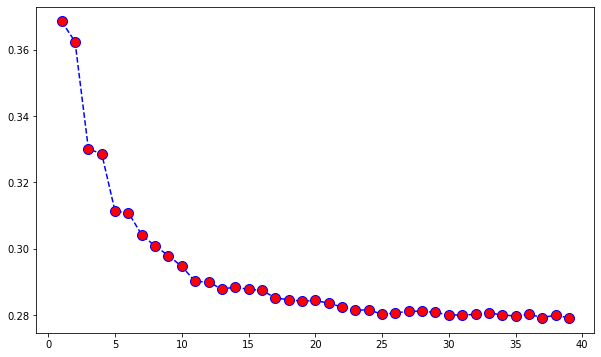

```python
plt.figure(figsize = (10,6))
plt.plot(range(1,40), error_rate, color = 'blue', linestyle ='--', marker = 'o',
       markerfacecolor = 'red', markersize = 10)
```

```python
knn = KNeighborsClassifier(n_neighbors =25)
knn.fit(X_train, y_train)
predictions_K = knn.predict(X_test)
```

```python
print(classification_report(y_test, predictions_K))
print(confusion_matrix(y_test, predictions_K))
```

```
              precision    recall  f1-score   support

           0       0.70      0.77      0.73     11377
           1       0.74      0.67      0.70     11213

    accuracy                           0.72     22590
   macro avg       0.72      0.72      0.72     22590
weighted avg       0.72      0.72      0.72     22590

[[8746 2631]
 [3700 7513]]
```

```python
accuracy_knn = accuracy_score(y_test, predictions_K)
accuracy_knn
```

```
0.719743249225321
```

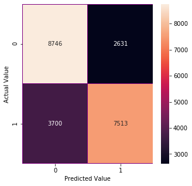

```python
cm = confusion_matrix(y_test, predictions_K)
f, ax = plt.subplots(figsize=(5,5))
sns.heatmap(cm,fmt=".0f", annot=True,linewidths=0.2, linecolor="purple", ax=ax)
plt.xlabel("Predicted Value")
plt.ylabel("Actual Value")
plt.show()
```

```python
from sklearn.metrics import plot_roc_curve
```

[output not shown]

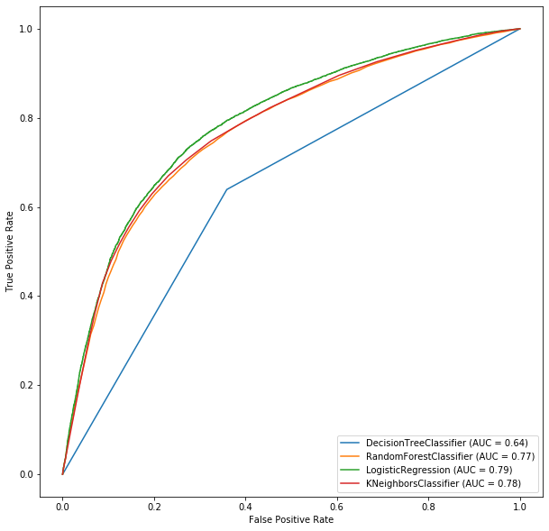

```python
disp = plot_roc_curve(dtree, X_test, y_test)

plot_roc_curve(rfc,X_test, y_test, ax = disp.ax_)

plot_roc_curve(logmodel,X_test, y_test, ax = disp.ax_)

plot_roc_curve(knn, X_test, y_test, ax = disp.ax_)
```

```python
result = []
results = pd.DataFrame(columns= ["Models","Accuracy"])

result = pd.DataFrame([["LogisticRegression", accuracy_log*100]], columns= ["Models","Accuracy"])
results = results.append(result)




result = pd.DataFrame([["RainForest", accuracy_rfc*100]], columns= ["Models","Accuracy"])
results = results.append(result)




result = pd.DataFrame([["DecisionTRee", accuracy_dtree*100]], columns= ["Models","Accuracy"])
results = results.append(result)


result = pd.DataFrame([["k_neighbors", accuracy_knn*100]], columns= ["Models","Accuracy"])
results = results.append(result)
```

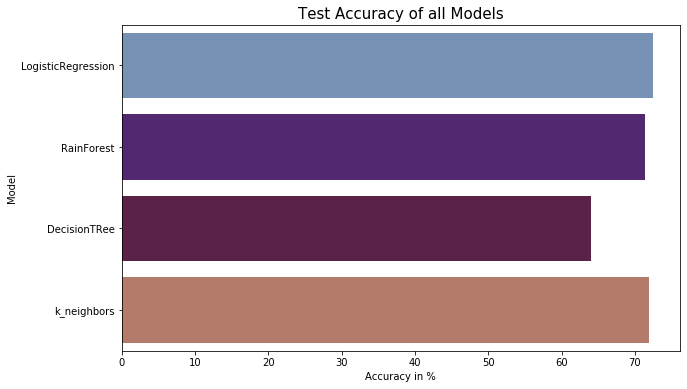

```python
fig, ax = plt.subplots(figsize=(10,6))
sns.barplot(x= 'Accuracy', y= 'Models',data = results, palette = 'twilight')

plt.title('Test Accuracy of all Models', fontsize= 15)
plt.ylabel('Model')
plt.xlabel('Accuracy in %')
```

Logistic Regression give us the better accuracy